# Análisis del paisaje

Autores

Afiliaciones

Víctor Gauto

[GISTAQ (UTN-FRRe)](https://www.instagram.com/gistaq.utn/)

[IIDTHH (UNNE, CONICET)](https://iidthh.conicet.gov.ar/)

[Instituto Gulich (UNC, CONAE)](https://ig.conae.unc.edu.ar/)

Sofía Paná

[Instituto Gulich (UNC, CONAE)](https://ig.conae.unc.edu.ar/)

[IREA](http://irea.cnr.it/)

Fecha de publicación

12 de julio de 2025

El paquete usado es [`{rflsgen}`](https://dimitri-justeau.github.io/rflsgen/), **Neutral Landscape Generator with Targets on Landscape Indices**.

**Precaución**

Antes que nada hay que ejecutar los siguientes comandos:

```r
options(
  java.parameters = c("-XX:+UseConcMarkSweepGC", "-Xmx36g")
)
gc()
```

Esto permite aumentar la memoria disponible para las funciones de `{rflsgen}`.

Los paquetes usados son los siguientes:

```r
library(tidyverse)
library(gt)
library(landscapemetrics)
library(NLMR)
library(rflsgen)
library(patchwork)
library(terra)
```

# 1 Lectura de datos

Inicialmente hay que leer los ráster de uso de suelo (`r`) y modelo digital de elevación (`dem`).

**Ver código**

```r
r <- rast("datos/r.tif")
dem <- rast("datos/dem.tif")
```

Las clases de `r` son:

| Valor | Tipo |
| --- | --- |
| 0 | No data |
| 10 | Forest |
| 20 | Scrubland |
| 30 | Grassland |
| 40 | Agriculture |
| 50 | Urban |
| 60 | Sparse vegetation - bare soil |
| 80 | Water body |

Agrego las categorías a `r` e incorporo colores. Visualizo ambos ráster.

**Ver código**

```r
d <- read_delim(
  file = "datos/LULCcode.txt",
  delim = "$ ",
  col_names = c("value"),
  show_col_types = FALSE
) |>
  separate_wider_delim(
    delim = " ",
    cols = value,
    names = c("value", "tipo"),
    too_many = "merge"
  ) |>
  mutate(value = as.integer(value)) |>
  filter(value != 0) |>
  mutate(col = c(
    "#E41A1C", "#377EB8", "#4DAF4A", "#984EA3", "#FF7F00", "#A65628", "#F781BF"
  ))

col_df <- d |>
  select(-tipo) |>
  as.data.frame()

# incorporo categorías y colores
levels(r) <- d
coltab(r) <- col_df
```

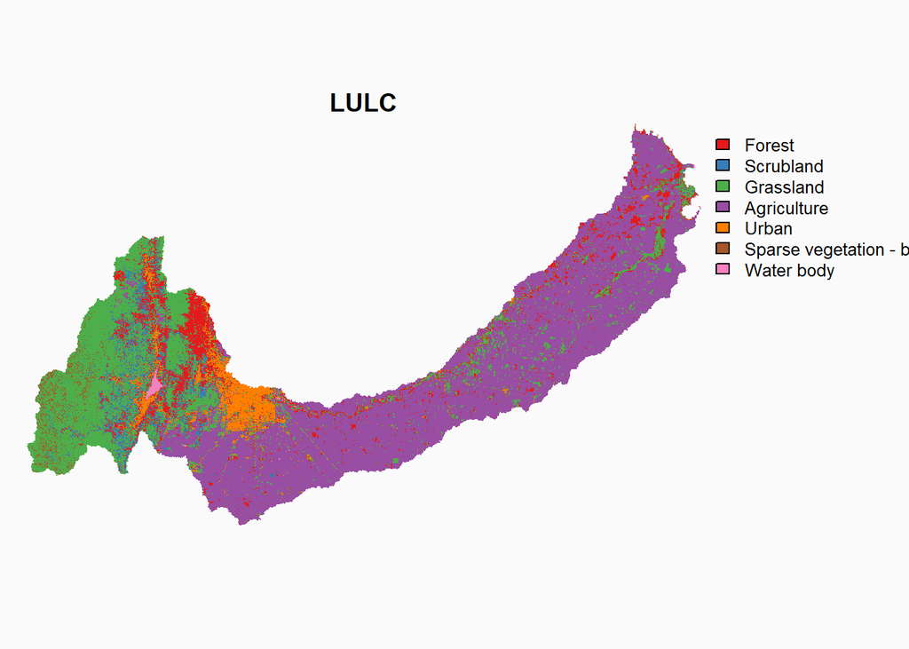

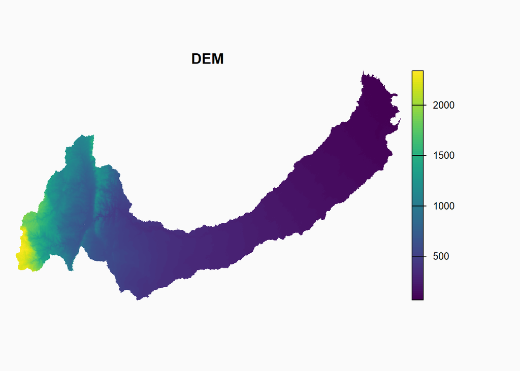

# 2 Extracción de la estructura del paisaje

Se seleccionan las clases de interés del ráster de cobertura del suelo.

**Ver código**

```r
clases <- c(30, 40, 50) # Grassland, Agriculture, Urban

estructura <- flsgen_extract_structure_from_raster(
  raster_file = r,
  focal_classes = clases,
  connectivity = 8
)
```

A partir de `estructura` y `dem` se genera un paisaje, indicando dependencia del terreno, conectividad, rugosidad y parámetros de posición.

Para visualizar el efecto de la dependencia del terreno (`terrain_dependency`) se generan 10 escenarios con valores crecientes entre 0,1 y 1,0.

**Ver código**

```r
f_dependencia <- function(x) {
  print(paste0("Dependencia del terreno: ", x))

  r_land <- flsgen_generate(
    estructura,
    terrain_file = dem,
    terrain_dependency = x,
    connectivity = 8,
    epsg = "EPSG:22174",
    resolution_x = res(r)[1],
    resolution_y = res(r)[2],
    x = ext(dem)$"xmin",
    y = ext(dem)$"ymax"
  )

  writeRaster(r_land, filename = paste0("rasters/land-", x, ".tif"))
}

dependencias <- seq(.1, 1, .1)
walk(dependencias, f_dependencia)
```

Se muestran a continuación los escenarios para las dependencias del terreno 0,1, 0,3, 0,7 y 1,0.

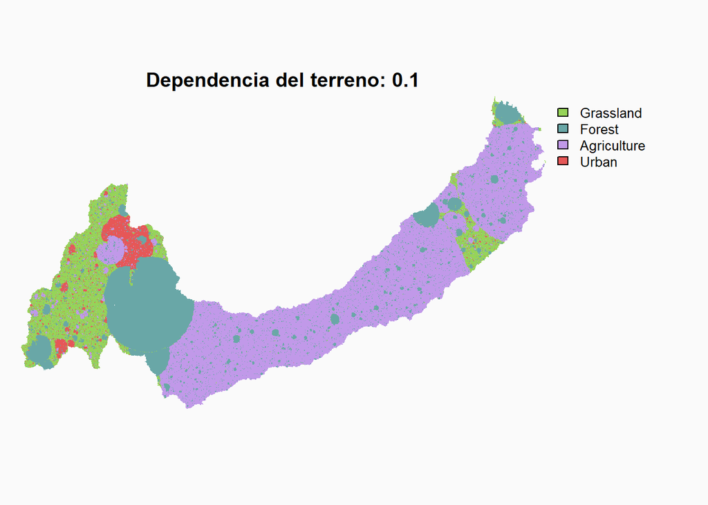

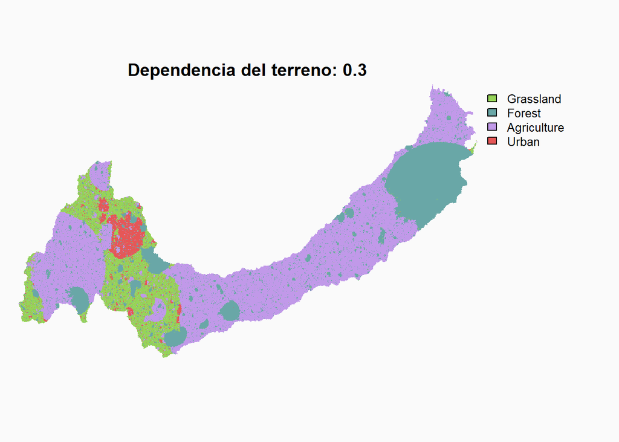

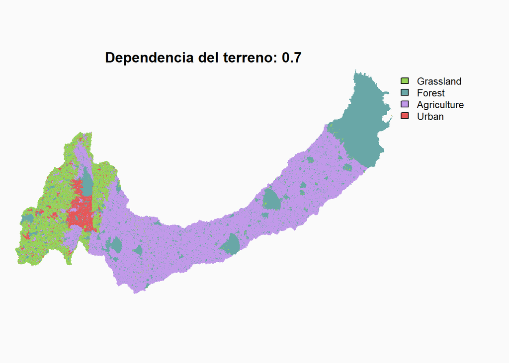

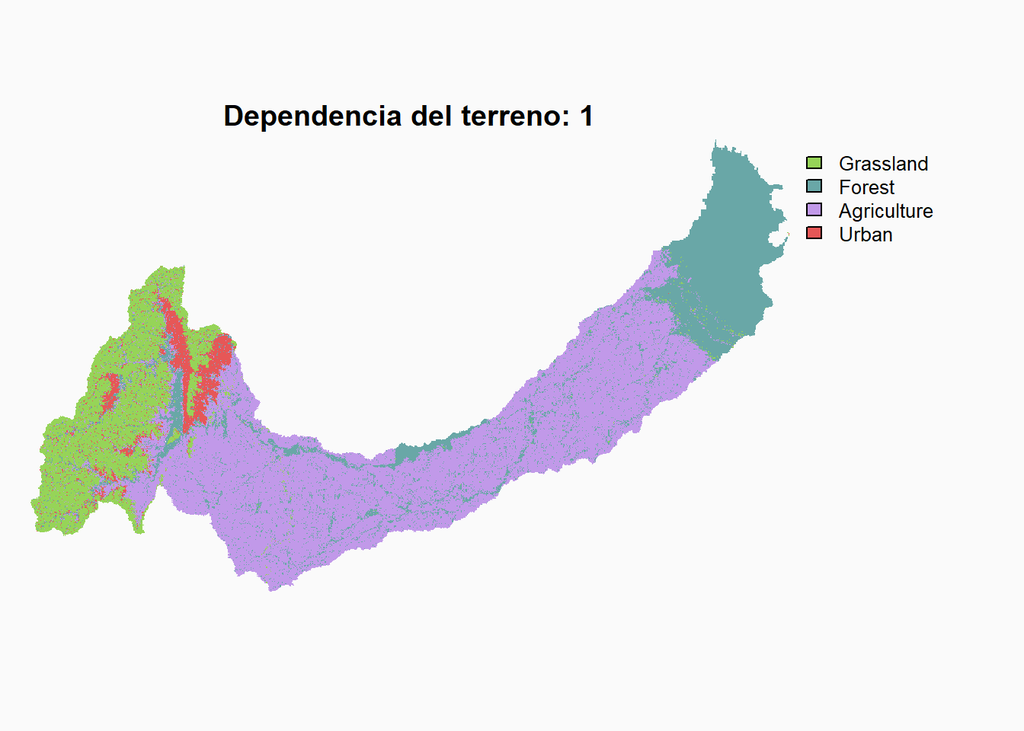

En la generación de los escenarios pueden suceder dos errores:

- **Falta de memoria**, al no contar con la suficiente capacidad de procesamiento. Para solucionarlo se puede reducir el tamaño de la región de interés, aumentar el tamaño de píxel o disminuir el número de clases.
- **Incapacidad de generar el ráster**, mostrando el siguiente mensaje:

```r
Could not generate a raster satisfying the input landscape structure
```

Esto puede solucionarse eligiendo únicamente las clases de interés.

# 3 Cálculo de métricas del paisaje

Para el cálculo de las métricas se utiliza el paquete [`{landscapemetrics}`](https://r-spatialecology.github.io/landscapemetrics/).

Las métricas se dividen en parche, clase y paisaje. A continuación se muestran los resultados para los escenarios considerando todas las dependencias del terreno.

## 3.1 Cálculo de métricas a nivel de clase

Las métricas del paisaje a nivel de clase devuelven un valor asociado a cada categoría del ráster de interés.

Se calcularon en total 32 métricas de clase. Las métricas que son independientes de las dependencias del terreno se muestran en la siguiente tabla.

**Ver código**

```r
f_contenido_funcion <- function(x) {
  tools::Rd_db("landscapemetrics")[[paste0("lsm_c_", x, ".Rd")]] |>
    as.character()
}

f_titulo_funcion <- function(x) {
  if (str_count(x, "\\(") == 1) {
    r <- str_trim(str_replace(x, " \\(.*?\\)", ""))
  } #else {
  #   r <- str_trim(str_extract(x, "^.*?\\(.*?\\)[^()]*")) # OK
  # }

  if (str_count(x, "\\(") == 2) {
    r <- str_trim(str_extract(x, "^.*?\\(.*?\\)[^()]*"))
  }

  if (str_count(x, "\\(") == 0) {
    r <- str_trim(x)
  }

  return(r)
}

f_eq <- function(x) {
  id_eq <- which(x == "\\deqn") + 3
  x[id_eq]
}

m_clase |>
  filter(as.numeric(metric) <= 12) |>
  reframe(
    v = median(valor),
    .by = c(tipo, metric)
  ) |>
  pivot_wider(
    names_from = tipo,
    values_from = v
  ) |>
  mutate(
    txt = map(metric, f_contenido_funcion)
  ) |>
  mutate(
    titulo = map_chr(txt, ~.x[16])
  ) |>
  mutate(
    eq = map_chr(txt, f_eq)
  ) |>
  mutate(eq = paste0("$$", eq, "$$")) |>
  mutate(titulo = map_chr(titulo, f_titulo_funcion)) |>
  mutate(
    link = paste0(
      "https://r-spatialecology.github.io/landscapemetrics/reference/lsm_c_",
      metric,
      ".html"
    )
  ) |>
  mutate(
    titulo = glue::glue("[{titulo}]({link})")
  ) |>
  select(Métrica = titulo, Grassland, Forest, Agriculture, Urban) |>
  gt() |>
  fmt_auto(
    columns = c(Grassland, Forest, Agriculture, Urban),
    locale = "es"
  ) |>
  tab_style(
    locations = cells_body(columns = c(Grassland, Forest, Agriculture, Urban)),
    style = cell_text(font = "JetBrains Mono", color = "black")
  ) |>
  tab_style(
    locations = cells_body(columns = c(Métrica)),
    style = cell_text(align = "left")
  ) |>
  fmt_url(columns = Métrica, color = "#8E063B") |>
  as_raw_html()
```

Métricas de clase independientes de la dependencia del terreno.

| Métrica | Grassland | Forest | Agriculture | Urban |
| --- | --- | --- | --- | --- |
| [Mean of patch area](https://r-spatialecology.github.io/landscapemetrics/reference/lsm_c_area_mn.html) | 1,049 | 3,518 | 29,537 | 1,882 |
| [Total (class) area](https://r-spatialecology.github.io/landscapemetrics/reference/lsm_c_ca.html) | 111.216,18 | 161.353,18 | 363.546,06 | 28.810,5 |
| [Mean of core area](https://r-spatialecology.github.io/landscapemetrics/reference/lsm_c_core_mn.html) | 0,91 | 3,085 | 27,986 | 1,483 |
| [Core area percentage of landscape](https://r-spatialecology.github.io/landscapemetrics/reference/lsm_c_cpland.html) | 14,477 | 21,281 | 51,803 | 3,416 |
| [Landscape division index](https://r-spatialecology.github.io/landscapemetrics/reference/lsm_c_division.html) | 0,983 | 0,983 | 0,837 | 0,999 |
| [Largest patch index](https://r-spatialecology.github.io/landscapemetrics/reference/lsm_c_lpi.html) | 12,864 | 12,821 | 38,491 | 2,593 |
| [Effective Mesh Size](https://r-spatialecology.github.io/landscapemetrics/reference/lsm_c_mesh.html) | 11.424,251 | 11.194,37 | 108.247,679 | 454,133 |
| [Number of patches](https://r-spatialecology.github.io/landscapemetrics/reference/lsm_c_np.html) | 106.352 | 45.871 | 12.308 | 15.311 |
| [Patch density](https://r-spatialecology.github.io/landscapemetrics/reference/lsm_c_pd.html) | 15,995 | 6,899 | 1,851 | 2,303 |
| [Percentage of landscape of class](https://r-spatialecology.github.io/landscapemetrics/reference/lsm_c_pland.html) | 16,726 | 24,266 | 54,675 | 4,333 |
| [Splitting index](https://r-spatialecology.github.io/landscapemetrics/reference/lsm_c_split.html) | 58,203 | 59,398 | 6,143 | 1.464,166 |
| [Total core area](https://r-spatialecology.github.io/landscapemetrics/reference/lsm_c_tca.html) | 96.258,72 | 141.504,76 | 344.449,525 | 22.713,325 |

La métricas de clase que mostraron cambios con la dependencia del terreno se observan en la figura de líneas.

**Ver código**

```r
g1 <- m_clase |>
  filter(as.numeric(metric) > 12) |>
  nest(.by = metric) |>
  mutate(
    txt = map(metric, f_contenido_funcion)
  ) |>
  mutate(
    titulo = map_chr(txt, ~.x[16])
  ) |>
  mutate(titulo = map_chr(titulo, f_titulo_funcion)) |>
  mutate(titulo = str_wrap(titulo, 17)) |>
  unnest(data) |>
  mutate(titulo = fct_reorder(titulo, as.numeric(metric))) |>
  ggplot(aes(dependencia_terreno, valor, color = tipo, group = tipo)) +
  geom_line(alpha = .8) +
  facet_wrap(vars(titulo), scales = "free", ncol = 10) +
  scale_x_continuous(
    breaks = seq(.1, 1, .1),
    labels = c("0,1", "", "", "", "", "", "", "", "", "1"),
    expand = c(0, 0),
    name = NULL
  ) +
  scale_y_continuous(
    name = NULL,
    labels = scales::label_number(big.mark = ".", decimal.mark = ",")
  ) +
  scale_color_manual(
    name = NULL,
    breaks = d_r$tipo,
    values = d_r$col
  ) +
  guides(
    color = guide_legend(override.aes = list(linewidth = 2))
  ) +
  theme_bw(base_size = 10, base_family = "Lato") +
  theme(
    aspect.ratio = 1,
    plot.margin = margin(r = 10),
    plot.background = element_blank(),
    panel.background = element_blank(),
    panel.spacing.x = unit(10, "pt"),
    panel.grid.minor = element_blank(),
    panel.grid.major = element_line(linewidth = .1, color = "grey"),
    legend.position = "top",
    legend.text = element_text(margin = margin(r = 10)),
    axis.text = element_text(size = rel(.6), color = "black"),
    axis.ticks = element_blank(),
    axis.text.y = element_text(margin = margin(r = 0)),
    strip.text = element_text(face = "bold", hjust = 0, size = rel(.7)),
    strip.background = element_blank(),
    strip.clip = "off"
  )

ggsave(
  plot = g1,
  filename = "figuras/metricas_clase_dif.png",
  width = 30,
  height = 8.5,
  units = "cm"
)
```

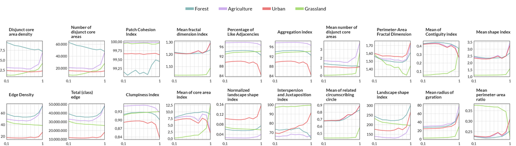

Métricas de clase variables con la dependencia del terreno.

## 3.2 Cálculo de métricas a nivel de paisaje

Se muestra a continuación una tabla que resume los valores de las métricas que se mantuvieron constantes, mostrando un único valor por cada métrica.

**Ver código**

```r
f_contenido_funcion2 <- function(x) {
  tools::Rd_db("landscapemetrics")[[paste0("lsm_l_", x, ".Rd")]] |>
    as.character()
}

m_paisaje |>
  filter(as.numeric(metric) <= 10) |>
  reframe(
    v = median(valor),
    .by = metric
  ) |>
  mutate(
    txt = map(metric, f_contenido_funcion2)
  ) |>
  mutate(
    titulo = map_chr(txt, ~.x[16])
  ) |>
  mutate(
    eq = map_chr(txt, f_eq)
  ) |>
  mutate(eq = paste0("$$", eq, "$$")) |>
  mutate(titulo = map_chr(titulo, f_titulo_funcion)) |>
  mutate(
    link = paste0(
      "https://r-spatialecology.github.io/landscapemetrics/reference/lsm_l_",
      metric,
      ".html"
    )
  ) |>
  mutate(
    titulo = glue::glue("[{titulo}]({link})")
  ) |>
  select(Métrica = titulo, Valor = v) |>
  gt() |>
  fmt_auto(
    columns = Valor,
    locale = "es"
  ) |>
  tab_style(
    locations = cells_body(columns = Valor),
    style = cell_text(font = "JetBrains Mono", color = "black")
  ) |>
  tab_style(
    locations = cells_body(columns = c(Métrica)),
    style = cell_text(align = "left")
  ) |>
  fmt_url(columns = Métrica, color = "#8E063B") |>
  as_raw_html()
```

Métricas de paisaje independientes de la dependencia del terreno.

| Métrica | Valor |
| --- | --- |
| [Largest patch index](https://r-spatialecology.github.io/landscapemetrics/reference/lsm_l_lpi.html) | 38,491 |
| [Modified Simpson's diversity index](https://r-spatialecology.github.io/landscapemetrics/reference/lsm_l_msidi.html) | 0,948 |
| [Modified Simpson's evenness index](https://r-spatialecology.github.io/landscapemetrics/reference/lsm_l_msiei.html) | 0,684 |
| [Patch richness](https://r-spatialecology.github.io/landscapemetrics/reference/lsm_l_pr.html) | 4 |
| [Patch richness density](https://r-spatialecology.github.io/landscapemetrics/reference/lsm_l_prd.html) | 6,016 × 10<sup>−4</sup> |
| [Shannon's diversity index](https://r-spatialecology.github.io/landscapemetrics/reference/lsm_l_shdi.html) | 1,109 |
| [Shannons's evenness index](https://r-spatialecology.github.io/landscapemetrics/reference/lsm_l_shei.html) | 0,8 |
| [Simpson's diversity index](https://r-spatialecology.github.io/landscapemetrics/reference/lsm_l_sidi.html) | 0,612 |
| [Simpson's evenness index](https://r-spatialecology.github.io/landscapemetrics/reference/lsm_l_siei.html) | 0,816 |
| [Total area](https://r-spatialecology.github.io/landscapemetrics/reference/lsm_l_ta.html) | 664.925,92 |

Con las métricas del paisaje que varían con la dependencia del terreno se creó la siguiente figura.

**Ver código**

```r
g2 <- m_paisaje |>
  filter(as.numeric(metric) > 10) |>
  nest(.by = metric) |>
  mutate(
    txt = map(metric, f_contenido_funcion2)
  ) |>
  mutate(
    titulo = map_chr(txt, ~.x[16])
  ) |>
  mutate(titulo = map_chr(titulo, f_titulo_funcion)) |>
  mutate(titulo = str_wrap(titulo, 17)) |>
  unnest(data) |>
  mutate(titulo = fct_reorder(titulo, as.numeric(metric))) |>
  ggplot(aes(dependencia_terreno, valor, group = metric)) +
  geom_line(alpha = .8, color = "#8E063B") +
  facet_wrap(vars(titulo), scales = "free", ncol = 8) +
  scale_x_continuous(
    breaks = seq(.1, 1, .1),
    labels = c("0,1", "", "", "", "", "", "", "", "", "1"),
    expand = c(0, 0),
    name = NULL
  ) +
  scale_y_continuous(
    name = NULL,
    labels = scales::label_number(big.mark = ".", decimal.mark = ",")
  ) +
  scale_color_manual(name = NULL) +
  guides(
    color = guide_legend(override.aes = list(linewidth = 2))
  ) +
  theme_bw(base_size = 10, base_family = "Lato") +
  theme(
    aspect.ratio = 1,
    plot.margin = margin(r = 10),
    plot.background = element_blank(),
    panel.background = element_blank(),
    panel.spacing.x = unit(10, "pt"),
    panel.grid.minor = element_blank(),
    panel.grid.major = element_line(linewidth = .1, color = "grey"),
    legend.position = "bottom",
    legend.text = element_text(margin = margin(r = 10)),
    axis.text = element_text(size = rel(.6), color = "black"),
    axis.ticks = element_blank(),
    axis.text.y = element_text(margin = margin(r = 0)),
    strip.text = element_text(face = "bold", hjust = 0, size = rel(.7)),
    strip.background = element_blank(),
    strip.clip = "off"
  )

ggsave(
  plot = g2,
  filename = "figuras/metricas_paisaje_dif.png",
  width = 30,
  height = 17,
  units = "cm"
)
```

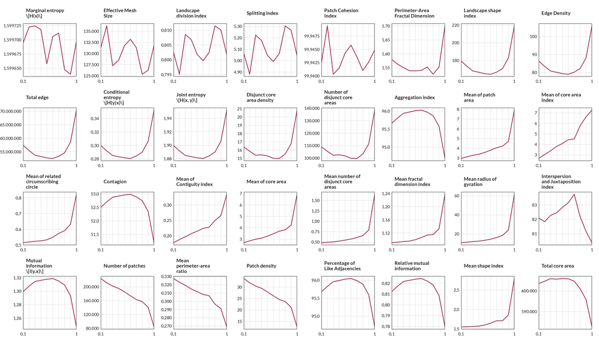

Métricas de paisaje variables con la dependencia del terreno.

# 4 Estructura del paisaje propia

Genero el **caso I** y el **caso II**, cada uno con dos clases y métricas del paisaje diferentes.

Luego, para verificar los escenarios generados, calculo las métricas y verifico que se cumplan las condiciones dadas.

[Defino](https://dimitri-justeau.github.io/rflsgen/reference/flsgen_create_class_targets.html) dos clases y sus métricas.

**Ver código**

```r
tibble(
  Clase = c("Clase 1", "Clase 2"),
  `Number of patches` = c("[700, 800]", "[800, 1100]"),
  `Patch area` = c("[5500, 14600]", "[9500, 11060]"),
  `Proportion of landscape` = c("10%", "-")
) |>
  gt() |>
  cols_label(
    `Number of patches` = md("Number of<br>patches"),
    `Proportion of landscape` = md("Proportion of<br>landscape"),
    "Clase" = ""
  ) |>
  tab_style(
    locations = cells_body(columns = -Clase),
    style = cell_text(font = "JetBrains Mono", color = "black")
  ) |>
  tab_header(title = md("**Caso I**"))
```

**Caso I**

|  | Number of patches | Patch area | Proportion of landscape |
| --- | --- | --- | --- |
| Clase 1 | [700, 800] | [5500, 14600] | 10% |
| Clase 2 | [800, 1100] | [9500, 11060] | - |

**Ver código**

```r
tibble(
  Clase = c("Clase A", "Clase B"),
  `Number of patches` = c("[700, 800]", "[700, 800]"),
  `Patch area` = c("[15500, 114600]", "[15500, 114600]"),
  `Proportion of landscape` = c("-", "25%")
) |>
  gt() |>
  cols_label(
    `Number of patches` = md("Number of<br>patches"),
    `Proportion of landscape` = md("Proportion of<br>landscape"),
    "Clase" = ""
  ) |>
  tab_style(
    locations = cells_body(columns = -Clase),
    style = cell_text(font = "JetBrains Mono", color = "black")
  ) |>
  tab_header(title = md("**Caso II**"))
```

**Caso II**

[output not shown]

```r
# CASO I
cls_1 <- flsgen_create_class_targets(
  class_name = "Clase 1",
  NP = c(700, 800),
  AREA = c(5500, 14600),
  PLAND = c(10, 10)
)

cls_2 <- flsgen_create_class_targets(
  class_name = "Clase 2",
  NP = c(800, 1100),
  AREA = c(9500, 11060)
)

# CASO II
cls_A <- flsgen_create_class_targets(
  class_name = "Clase A",
  NP = c(700, 800),
  AREA = c(15500, 114600)
)

cls_B <- flsgen_create_class_targets(
  class_name = "Clase B",
  NP = c(700, 800),
  AREA = c(15500, 114600)
)
```

Las métricas y los valores tienen que ser coherentes y no pueden adoptar cualquier número. En caso de indicar valores incorrectos, se muestra el siguiente mensaje de error:

```r
User targets cannot be satisfied
```

[Creo](https://dimitri-justeau.github.io/rflsgen/reference/flsgen_create_landscape_targets.html) un conjunto con las clases y obtengo la estructura, utilizando el `dem` como máscara.

**Ver código**

```r
# CASO I
objetivos <- flsgen_create_landscape_targets(
  mask_raster = dem,
  classes = list(cls_1, cls_2)
)

estructura_custom <- flsgen_structure(objetivos)

# CASO II
objetivos2 <- flsgen_create_landscape_targets(
  mask_raster = dem,
  classes = list(cls_A, cls_B)
)

estructura_custom2 <- flsgen_structure(objetivos2)
```

Genero un ráster a partir de las clases creadas y su estructura ubicados sobre el `dem` original.

**Ver código**

```r
r_custom <- flsgen_generate(
  estructura_custom,
  terrain_file = dem,
  terrain_dependency = 1,
  connectivity = 8,
  epsg = "EPSG:22174",
  resolution_x = res(r)[1],
  resolution_y = res(r)[2],
  x = ext(dem)$"xmin",
  y = ext(dem)$"ymax"
)

writeRaster(r_custom, "rasters/r_custom.tif", overwrite = TRUE)

r_custom2 <- flsgen_generate(
  estructura_custom2,
  terrain_file = dem,
  terrain_dependency = 1,
  connectivity = 8,
  epsg = "EPSG:22174",
  resolution_x = res(r)[1],
  resolution_y = res(r)[2],
  x = ext(dem)$"xmin",
  y = ext(dem)$"ymax"
)

writeRaster(r_custom2, "rasters/r_custom2.tif", overwrite = TRUE)
```

Visualizo los resultados de ambos casos.

**Ver código**

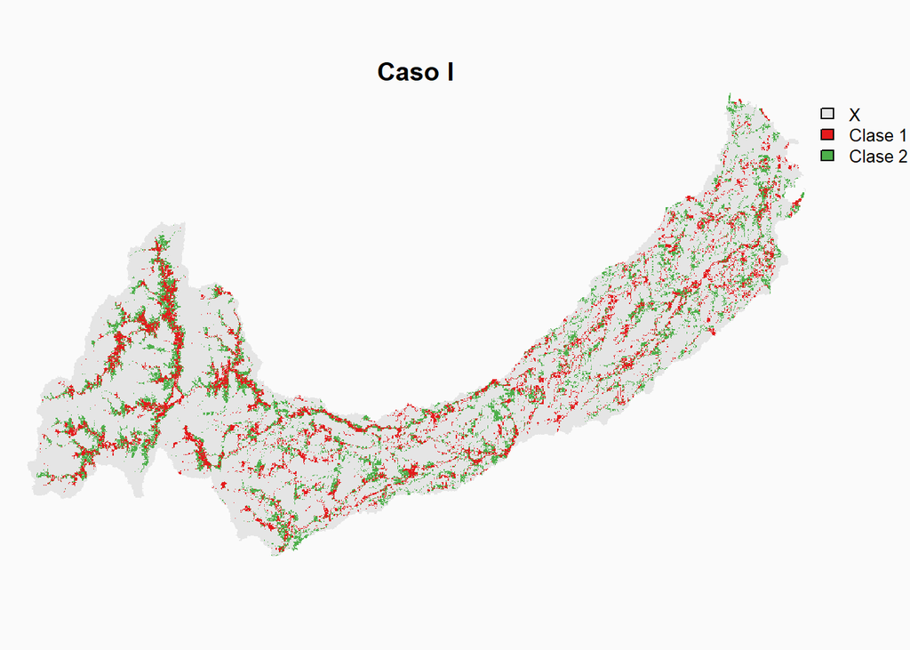

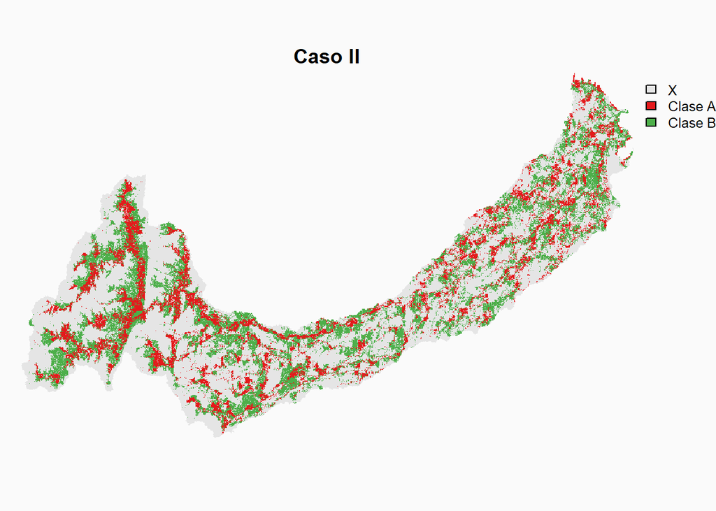

```r
r_custom <- rast("rasters/r_custom.tif")

d_custom <- tibble(
  value = as.integer(c(0, 1)),
  tipo = c("Clase 1", "Clase 2"),
  col = c("#E41A1C", "#4DAF4A")
) |>
  add_row(
    value = as.integer(-1),
    tipo = "X",
    col = "grey90"
  )

col_df_custom <- d_custom |>
  select(-tipo) |>
  as.data.frame()

# incorporo categorías y colores
levels(r_custom) <- d_custom
coltab(r_custom) <- col_df_custom

par(bg = "#FAFAFA")

plot(
  r_custom, axes = FALSE, mar = c(1, 1, 1, 4), main = "Caso I",
  background = "#FAFAFA"
)
r_custom2 <- rast("rasters/r_custom2.tif")

d_custom2 <- tibble(
  value = as.integer(c(0, 1)),
  tipo = c("Clase A", "Clase B"),
  col = c("#E41A1C", "#4DAF4A")
) |>
  add_row(
    value = as.integer(-1),
    tipo = "X",
    col = "grey90"
  )

col_df_custom2 <- d_custom2 |>
  select(-tipo) |>
  as.data.frame()

# incorporo categorías y colores
levels(r_custom2) <- d_custom2
coltab(r_custom2) <- col_df_custom2

plot(
  r_custom2, axes = FALSE, mar = c(1, 1, 1, 4), main = "Caso II",
  background = "#FAFAFA"
)
```

Verifico que el ráster creado tenga las métricas previamente definidas para cada clase.

**Ver código**

```r
read_tsv("datos/df_custom.tsv", show_col_types = FALSE) |>
  filter(class != -1) |>
  mutate(
    clase = if_else(class == 0, "Clase 1", "Clase 2")
  ) |>
  pivot_wider(
    names_from = metrica,
    values_from = value,
    id_cols = clase
  ) |>
  select(clase, `Number of patches`, `Percentage of landscape of class`) |>
  gt() |>
  cols_label(
    `Number of patches` = md("Number of<br>patches"),
    `Percentage of landscape of class` = md("Percentage of<br>landscape of class"),
    "clase" = ""
  ) |>
  tab_style(
    locations = cells_body(columns = -clase),
    style = cell_text(font = "JetBrains Mono", color = "black")
  ) |>
  fmt_number(
    columns = 2,
    dec_mark = ",",
    decimals = 0,
    sep_mark = "."
  ) |>
  fmt_number(
    columns = 3,
    dec_mark = ",",
    decimals = 1,
    sep_mark = "."
  ) |>
  tab_header(title = md("**Caso I**"))
```

**Caso I**

|  | Number of patches | Percentage of landscape of class |
| --- | --- | --- |
| Clase 1 | 791 | 10,0 |
| Clase 2 | 806 | 11,5 |

**Ver código**

```r
read_tsv("datos/df_custom2.tsv", show_col_types = FALSE) |>
  filter(class != -1) |>
  mutate(
    clase = if_else(class == 0, "Clase A", "Clase B")
  ) |>
  pivot_wider(
    names_from = metrica,
    values_from = value,
    id_cols = clase
  ) |>
  select(clase, `Number of patches`, `Percentage of landscape of class`) |>
  gt() |>
  cols_label(
    `Number of patches` = md("Number of<br>patches"),
    `Percentage of landscape of class` = md("Percentage of<br>landscape of class"),
    "clase" = ""
  ) |>
  tab_style(
    locations = cells_body(columns = -clase),
    style = cell_text(font = "JetBrains Mono", color = "black")
  ) |>
  fmt_number(
    columns = 2,
    dec_mark = ",",
    decimals = 0,
    sep_mark = "."
  ) |>
  fmt_number(
    columns = 3,
    dec_mark = ",",
    decimals = 1,
    sep_mark = "."
  ) |>
  tab_header(title = md("**Caso II**"))
```

**Caso II**

|  | Number of patches | Percentage of landscape of class |
| --- | --- | --- |
| Clase A | 701 | 16,3 |
| Clase B | 753 | 25,0 |